# Epidemiology, Prognosis, and Treatment of Resistant Hypertension - Smith - 2013 - Pharmacotherapy: The Journal of Human Pharmacology and Drug Therapy - Wiley Online Library

[Pharmacotherapy: The Journal of Human Pharmacology and Drug Therapy](https://accpjournals.onlinelibrary.wiley.com/journal/18759114)

[Volume 33, Issue 10](https://accpjournals.onlinelibrary.wiley.com/toc/18759114/2013/33/10) p. 1071-1086

[figure not shown]

Review of Therapeutics

Full Access

# Epidemiology, Prognosis, and Treatment of Resistant Hypertension

[Steven M. Smith](https://accpjournals.onlinelibrary.wiley.com/action/doSearch?ContribAuthorRaw=Smith%2C+Steven+M),

Address for correspondence: Steven M. Smith, Department of Clinical Pharmacy, Skaggs School of Pharmacy and Pharmaceutical Sciences, University of Colorado, 12850 E. Montview Boulevard, Mailstop C238, Aurora, CO 80045; e-mail: .

First published: 30 May 2013

https://doi.org/10.1002/phar.1297

Citations: 11

## Abstract

Resistant hypertension is a common clinical problem, which, until recently, has received little attention in the medical literature. With this increased attention has come a considerably better understanding of disease epidemiology, prognosis, and treatment, yet much remains unknown. Current data suggest that the prevalence of resistant hypertension has been increasing in recent decades, a concerning finding given that resistant hypertension appears to be associated with a poorer prognosis than nonresistant hypertension. The most appropriate management for these patients has not been fully elucidated, but a multifaceted approach incorporating accurate diagnosis, identification, and removal of substances that interfere with blood pressure, dietary and lifestyle management, and treatment with rational drug combination therapy can be quite effective in controlling blood pressure in these patients. Newer therapies, both pharmacologic and interventional procedures, are under study and may hold promise in the future treatment of resistant hypertension. This review highlights recent research on disease epidemiology and prognosis, and it describes the current body of literature on the treatment of this increasingly common condition.

Hypertension is a major risk factor for coronary heart disease and stroke, and it remains the most common chronic disease worldwide, affecting an estimated 76.4 million adults in the United States and upward of 1 billion persons globally.1, 2 Despite the ubiquity of this disease and the vast number of effective treatments, nearly one of every two persons with hypertension in the United States remain uncontrolled.3 The reasons for this high level of uncontrolled hypertension are not fully known; however, clinical inertia, suboptimal treatment regimens, inadequate patient follow-up, and treatment nonadherence are among the likely contributors. Even in those who overcome these barriers, a sizable proportion will remain uncontrolled—so-called resistant hypertension.

In the late 1970s, a sentinel review suggested that resistant hypertension was a rare and diminishing phenomenon.4 Indeed, until recent years, relatively little attention was paid to the concept of resistant hypertension. At the time of this writing, only 636 publications with “resistant hypertension” in the title had been indexed in the Medline database, with over half of these (59.1% [376 publications]) published from 2008 onward, coinciding with publication of the first set of resistant hypertension guidelines.5 As the evidence base, and the concept of evidence-based medicine, have grown in recent years, so too has the recognition that resistant hypertension is a common and challenging clinical problem for patients, primary care providers, and hypertension specialists. This review highlights recent findings in the epidemiology, prognosis, and pathophysiology of resistant hypertension, and it discusses the current evidence regarding treatment of this increasingly common disease.

## Definition, Epidemiology, and Prognosis of Resistant Hypertension

### Definition and Diagnosis

In 2008 the American Heart Association published the first scientific statement regarding the diagnosis, evaluation, and management of resistant hypertension.5 In this statement, they defined resistant hypertension as “blood pressure that remains above goal in spite of the concurrent use of three antihypertensive agents of different classes.”5 More simply, resistant hypertension is hypertension that requires four or more drugs to control blood pressure. The guidelines further stipulate that, ideally, at least one agent should be a diuretic, and all agents should be optimally dosed, although the type of diuretic and the optimal doses for any given agent are not specified. Generally, *diuretic* refers to a thiazide or thiazide-like diuretic, although in some patient populations (e.g., severe chronic kidney disease), appropriately dosed loop diuretic therapy meets this definition. In contrast, *optimal doses* for some agents are not as clearly defined or always well known among clinicians.

Importantly, the diagnosis of resistant hypertension is in many ways a diagnosis of exclusion. Specifically, secondary causes of hypertension, especially those that are quite common (e.g., obstructive sleep apnea and primary hyperaldosteronism), should be considered, particularly in patients with difficult-to-treat hypertension despite optimal doses of appropriate combination therapy. Although these patients can often present with apparent drug-resistant hypertension, their blood pressure elevation usually can be substantially reduced or eliminated with one or two treatments targeting the root cause. Thus these patients usually do not exhibit true drug-resistant hypertension. In addition, resistant hypertension must be differentiated from pseudo-resistant hypertension, which can occur with poor blood pressure measurement technique,6 medication nonadherence,7 inappropriate prescribing,8 the white-coat effect,9 or in patients taking concomitant interfering substances (e.g., nonsteroidal antiinflammatory drugs [NSAIDs]). In particular, the diagnosis is ideally made by using 24-hour ambulatory blood pressure monitoring to exclude patients who have a white-coat effect because they can constitute a sizable portion (a third or more) of the apparent resistant hypertension population.10

Recent reports from several large cardiovascular clinical trials have shed light on common risk factors for the development of resistant hypertension. These risk factors include older age, higher baseline systolic blood pressure, obesity, and the presence of left ventricular hypertrophy, heart failure, chronic kidney disease, or diabetes mellitus (Table 1).11-13 Similar findings have been reported from the Framingham Heart Study.14 Excessive dietary salt intake is another common finding in patients with uncontrolled and resistant hypertension, and it plays a significant role in the high prevalence of volume overload and isolated systolic hypertension found in patients with resistant hypertension.5, 11, 14

Table 1. Baseline Predictors of Resistant Hypertension in Major Cardiovascular Trials

| Predictors | ALLHAT11 | ASCOT12 | INVEST13 |
| --- | --- | --- | --- |
| Age | Older age | NS | Older age |
| Sex | Female | Male | NR |
| Race/ethnicity | African-American | NAa | African-American |
| Baseline SBP | Higher | Higher | NR |
| Body mass index | Higher | Higher | Higher |
| Salt intake | Higher | NR | NR |
| Chronic kidney disease | Present | NSb | NR |
| Diabetes mellitus | Present | Present | Present |
| Left ventricular hypertrophy | Present | Present | Present |
| Heart failure | NR | NR | Present |
| History of stroke or TIA | NR | NR | Present |
| Geographic locationc | Resides in southern United States | NR | Resides in United States |

- Reported variables constitute only those with an adverse effect on development of resistant hypertension (e.g., a higher body mass index or the presence of left ventricular hypertrophy increased the risk of development of resistant hypertension across all three trials). Values in the ALLHAT column represent risk of uncontrolled hypertension at 3 yrs, not resistant hypertension as explicitly defined.
- ALLHAT = Antihypertensive and Lipid-Lowering Treatment to Prevent Heart Attack Trial; ASCOT = Anglo-Scandinavian Cardiac Outcomes Trial; INVEST = International Verapamil-Trandolapril Study; NS = nonsignificant; NA = not applicable; NR = not reported; SBP = systolic blood pressure; TIA = transient ischemic attack.
- <sup>*a*</sup> 98.6% of the participants enrolled in ASCOT were white; thus the significance of this finding is questionable.
- <sup>*b*</sup> The logistic regression model included creatinine levels (continuous variable) and microalbuminuria (dichotomous variable) but not specifically the presence of chronic kidney disease.
- <sup>*c*</sup> For ALLHAT, the comparison was with persons residing in the western United States; for INVEST, the comparison was with persons enrolled from outside the United States.

### Epidemiology

As may be obvious from the definition, the true prevalence of resistant hypertension is exceedingly difficult to determine accurately. Patients who take two or fewer antihypertensive agents may indeed have what amounts to resistant hypertension, but they are not classified as such because they may not strictly meet the definition of requiring four or more drugs to control their blood pressure. Thus a major limitation to the current definition is that it relies solely on the number of medications prescribed for, and taken by, the patient, and is therefore subject to excellent adherence and the absence of clinical inertia.

Our current knowledge of the prevalence of resistant hypertension comes largely from randomized clinical trials in hypertensive populations and from large survey studies such as the U.S. National Health and Nutrition Examination Survey (NHANES). In the Antihypertensive and Lipid-Lowering Treatment to Prevent Heart Attack Trial (ALLHAT), after 5 years of follow-up, 23% of participants required three or more antihypertensives for control, and nearly 10% of participants were taking four or more antihypertensives regardless of control.11 In the Anglo-Scandinavian Cardiac Outcomes Trial (ASCOT), a third of all previously untreated patients (1258 of 3666) and half of all treatment-randomized patients (9333 of 19,257) were classified as having resistant hypertension after a median follow-up period of 5.3 and 4.8 years, respectively.12 Data from NHANES over the last several decades suggest that the current prevalence of resistant hypertension among U.S. adults with hypertension is approximately 21%,15, 16 although this estimate may be imprecise given the relatively low number of persons with resistant hypertension in any given year of the NHANES data. Importantly, the prevalence of resistant hypertension appears to have increased substantially over the past several decades (Figure 1).15, 16 These data likely reflect a true increase in the prevalence of resistant hypertension; however, some of this increase may also be due to reduced clinical inertia with more recent emphasis on guideline concordance and evidence-based care.15, 17 Recent data from NHANES suggest that antihypertensive use is increasing substantially across all classes except for calcium channel blockers (Figure 2).17 Thus, although the prevalence of resistant hypertension is likely increasing, some of the increase may be artifactual for at least two reasons: many patients would have been previously classified as having resistant hypertension but were not treated aggressively enough to strictly meet the definition, and blood pressure goals have changed (mostly downward) over this time frame.

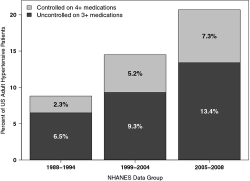

**Figure 1**

The prevalence of resistant hypertension appears to be increasing in the United States according to the U.S. National Health and Nutrition Examination Survey (NHANES) data from 1988 to 2008. (Data adapted from reference 15. Figure modified and used with permission from reference 16.)

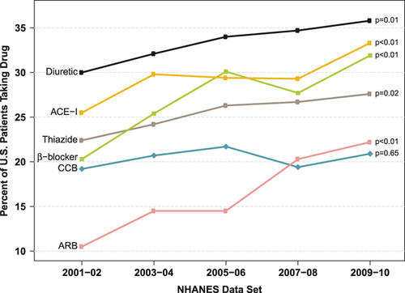

**Figure 2**

The little information available to date on the incidence of resistant hypertension comes mostly from large clinical trials. However, major limitations to studying the incidence in these trials are that their durations are often relatively short (5 years or less), they often exclude patients with very high blood pressure, and most trials do not enroll a high proportion of newly diagnosed patients. A recently published cohort study retrospectively analyzed a large hypertension registry dataset from two Kaiser health systems and found that 3960 (1.9%) of the 205,750 patients in the original cohort with newly diagnosed hypertension developed resistant hypertension (after excluding those with medication nonadherence) over the ensuing 18 months.18

### Prognosis

In the absence of published data in this patient population, the general consensus on prognosis has been that resistant hypertension, even if blood pressure is controlled, likely carries a higher cardiovascular risk than drug-responsive hypertension.5 This supposition is largely attributed to two primary factors: resistant hypertension is likely reflective of adverse processes (e.g., inappropriately high renin-angiotensin system [RAS] stimulation and aldosterone production, increased arterial stiffness) that have been linked with increased cardiovascular risk, and patients with resistant hypertension have likely had a greater blood pressure burden (e.g., more severe or more prolonged elevations in blood pressure) over time compared with their counterparts with controlled nonresistant hypertension. The former, in particular, is supported indirectly by a recent analysis of data from the Valsartan Antihypertensive Long-Term Use Evaluation (VALUE) trial, in which patients requiring only monotherapy for blood pressure control had a 20% lower risk of major adverse cardiovascular events compared with those with controlled blood pressure requiring combination therapy.19 Interestingly, the authors found no significant difference in risk between uncontrolled patients requiring combination therapy and controlled patients requiring combination therapy.

To date, few studies have compared major clinical outcomes between patients with resistant versus nonresistant hypertension. Several cross-sectional reports have indicated that resistant hypertension is associated with a higher prevalence of chronic kidney disease, congestive heart failure (and left ventricular hypertrophy), coronary artery disease, and stroke.9, 15, 20 One of the earliest longitudinal studies compared the risk of cardiovascular outcomes among patients with true resistant hypertension with those classified as having “responder hypertension” on the basis of ambulatory blood pressure monitoring.21 Event rates in the responder and true resistant hypertension groups were 0.87 and 4.1 per 100 patient-years, respectively, over 5 years of follow-up, for a relative risk (RR) of a cardiovascular event almost 200% higher (RR 2.94, 95% confidence interval [CI] 1.02–8.41, p<0.05) in those with true resistant hypertension compared with those who had hypertension adequately responsive to medication. Interestingly, nearly twice as many persons in the true resistant hypertension group used daily aspirin compared with the responder hypertension group (18.5% vs 9.7%, respectively), whereas 20.8% of persons in the true resistant hypertension group used NSAIDs compared with only 9.1% of those with responder hypertension.21

More recent data from Kaiser also suggest an increased risk of cardiovascular events in patients with resistant hypertension.18 Specifically, resistant hypertension was associated with an approximate 50% increase (18% vs 13.5%; unadjusted hazard ratio 1.54, 95% CI 1.40–1.69) in the composite outcome of death, myocardial infarction, congestive heart failure, stroke, or chronic kidney disease compared with patients with nonresistant hypertension.18 This finding was largely driven by differences in incident chronic kidney disease, which occurred in 14.5% of resistant hypertension patients and in only 10.4% of nonresistant hypertension patients. Perhaps the most salient finding, however, was that this analysis only included patients with newly diagnosed hypertension during the study period. Thus the duration of hypertension was similar between those with and without resistant hypertension, and consequently, the increased risk cannot be explained solely by an increased duration of uncontrolled blood pressure.

Finally, a recent analysis of the International Verapamil-Trandolapril Study (INVEST) found no significant difference in all-cause mortality between patients with resistant hypertension (regardless of control) versus patients with uncontrolled hypertension (taking one or two agents) among a cohort of individuals with coronary artery disease.13 However, both of the groups had higher all-cause mortality than patients with controlled blood pressure taking three or fewer agents. Taken together, these studies suggest that resistant hypertension does indeed carry greater adverse cardiovascular and renal risk than controlled nonresistant hypertension. Moreover, because no significant difference in mortality was found between uncontrolled and “resistant hypertension” patients, this suggests that uncontrolled (but not diagnosed as resistant) hypertensive patients may be similar in terms of risk, regardless of the number of medications being prescribed.13

## Treatment

Blood pressure reduction substantially reduces the risk of cardiovascular morbidity and mortality. Specifically, antihypertensive medications have been shown to reduce the risk of stroke by 20–39%, coronary heart disease by ~20%, and major adverse cardiovascular events by 15–28%, compared with placebo or less intensive therapies in randomized controlled trials.22 Although these data originate from general hypertensive populations, it stands to reason that similar (or perhaps greater) benefits would be afforded by blood pressure reduction in patients with resistant hypertension. However, no studies to date have prospectively assessed the benefit of aggressive blood pressure control in resistant hypertension compared with placebo or less aggressive therapy.

Treatment of resistant hypertension should involve a multifaceted approach incorporating identification and removal of interfering substances (e.g., NSAIDs), consideration of secondary hypertension and exclusion of pseudo-resistant hypertension, counseling and education on lifestyle and dietary management, and the use of an optimized multidrug regimen. Blood pressure goals depend on patient-specific characteristics and concomitant disease states, but for most patients, the goal clinic blood pressure remains less than 140/90 mm Hg according to the Seventh Report of the Joint National Committee on Prevention, Detection, Evaluation, and Treatment of High Blood Pressure guidelines.23 Exclusions to this goal include those with chronic kidney disease and urine albumin excretion of 30 mg/24 hours or higher (or an albumin-to-creatinine ratio of 30 mg/g or higher), in whom the blood pressure goal is 130/80 mm Hg or lower according to the 2012 Kidney Disease: Improving Global Outcomes guidelines,24 and those with diabetes, in whom the goal is less than 140/80 mm Hg according to the 2013 American Diabetes Association standards of care.25 Older individuals (more than 80 years) may require less aggressive therapy to avoid hypotension and its sequelae, and many clinicians will aim for a systolic blood pressure goal of less than 145 or 150 mm Hg in these patients.26 Home blood pressure and daytime 24-hour ambulatory blood pressure goals are generally 5 mm Hg lower (i.e., less than 135/85 mm Hg for patients with uncomplicated hypertension) than clinic blood pressure goals.

### Identification and Removal of Interfering Substances

A thorough history should identify potentially significant interfering substances (Table 2). When possible, these substances should be discontinued in favor of therapy that does not contribute to blood pressure elevations. If a drug is clinically necessary, therapy should be continued at the lowest effective dose. In some cases, antihypertensive therapy may be tailored according to the mechanism by which the substance increases blood pressure. For example, several lines of evidence suggest that angiogenesis inhibitors reduce nitric oxide synthesis, promote endothelin-1 production, and increase proteinuria.27 Thus agents targeting these mechanisms, such as nitrates, phosphodiesterase inhibitors, nebivolol, endothelin antagonists, or even angiotensin-converting enzyme (ACE) inhibitors or dihydropyridine calcium channel blockers, may theoretically be more effective in reducing blood pressure in these patients.27

Table 2. Commonly Known Substances That Can Interfere with Blood Pressure Control

| Drugs | Nondrug Substances |
| --- | --- |
| Nonsteroidal antiinflammatory drugsa | Alcohol (excessive long-term use) |
| Aspirin (usually high dose) | Natural licorice |
| Acetaminophen (usually high dose) | Sodium |
| Sympathomimetics (e.g., decongestants, cocaine, diet pills) | Caffeine (recent ingestion) |
| Stimulants (e.g., amphetamines, methylphenidate, modafinil) | Ephedra or ma huang |
| Oral contraceptives and estrogen (including danazol) | Guarana, bitter orange, blue cohosh |
| Ketoconazole | Nicotine (recent intake) |
| Cyclosporine, tacrolimus |  |
| Erythropoietin |  |
| Glucocorticoids and mineralocorticoids |  |
| Chemotherapeutic agents (e.g., angiogenesis inhibitors) |  |
| Anabolic steroids |  |
| Serotonin-norepinephrine reuptake inhibitors |  |

- <sup>*a*</sup> Includes both nonselective and cyclooxygenase-2–selective agents.

### Evaluation of Secondary and Pseudo-Resistant Hypertension

Secondary causes of hypertension and pseudo-resistant hypertension should be considered in patients with apparent resistant hypertension. For secondary hypertension, particular attention should be paid to obstructive sleep apnea and hyperaldosteronism because both appear to be quite common in resistant hypertension. Several reports over the last decade suggest that an incredible 64–83% of patients with apparent resistant hypertension have underlying obstructive sleep apnea.28-30 These patients appear to respond well to continuous positive airway pressure treatment, although results have been mixed.31-33 Hyperaldosteronism is also common among patients with apparent resistant hypertension, with prevalence estimates ranging from 17% to 22% in the United States and Europe.34 Diagnostic testing for both of these conditions is relatively straightforward, although cumbersome, particularly for obstructive sleep apnea. Such tests for secondary causes of hypertension generally are reserved for patients with uncontrolled blood pressure despite optimal pharmacologic intervention, especially when a thorough physical examination and history identifies clinical characteristics suggestive of these conditions. Other common causes of apparent treatment resistance, such as renal artery stenosis and renal parenchymal disease, are generally found in fewer than 5% of patients with resistant hypertension. Rare causes of secondary hypertension include pheochromocytoma, hyperparathyroidism, coarctation of the aorta, intracranial tumors, and Cushing disease.5 Specific diagnostic testing for these forms of secondary hypertension are not usually performed. Pseudoresistance should also be evaluated with particular attention paid to medication adherence and appropriate blood pressure measurement (ideally with 24-hour ambulatory blood pressure monitoring).

### Lifestyle and Dietary Management

#### Weight Reduction

Elevations in body mass index (BMI) and obesity have been consistently and independently associated with resistant hypertension in a variety of epidemiologic studies and clinical trials. In particular, a BMI higher than 30 kg/m<sup>2</sup> has been associated with a need for an increased number of antihypertensive agents, without a proportional increase in blood pressure control in both the Framingham study and the ALLHAT trial.11, 14 These patients often have even worse blood pressure control than their normal body weight peers, despite the use of additional antihypertensive therapy. Although the exact mechanism is likely complex and certainly poorly understood, obesity may promote resistant hypertension through impaired sodium excretion, alterations in sympathetic activity, stimulation of the RAS and aldosterone production, and several other routes.5, 35 Aside from the direct effects of increased weight on the cardiovascular system (and blood pressure), obesity is also a strong predictor of obstructive sleep apnea and thus may promote the development of resistant hypertension indirectly through this mechanism.

No trials to date have prospectively assessed the impact of weight loss on blood pressure or clinical outcomes in a specific resistant hypertension population. However, modest blood pressure reductions have been observed in many short-term studies of weight-loss drugs. Moreover, several systematic reviews have shown that blood pressure decreases by 0.6–1 mm Hg, on average, per kilogram of weight loss.35-37 Based on currently available data, it seems reasonable to assume that significant weight loss, particularly in more severely obese patients with resistant hypertension, may improve blood pressure control or at least reduce the need for additional antihypertensive agents.38 Importantly, weight-loss strategies should be multifaceted and include aerobic exercise, which has been shown to reduce daytime 24-hour ambulatory blood pressure significantly in patients with resistant hypertension, at least in the short term.39

#### Sodium Restriction

Sodium restriction has long been advocated for patients with hypertension because differences in sodium ingestion of as little as 100 mmol (2.3 g)/day among normo- and hypertensive persons has been associated with significant changes in blood pressure.40 More recent meta-analyses suggest even greater systolic blood pressure reductions (up to 7 mm Hg) in patients with hypertension who were administered low-salt interventions.41, 42 However, it should be noted that although the public health campaign on reducing dietary sodium intake has been significant, the data on sodium restriction and subsequent blood pressure and cardiovascular event reduction are mixed, and individual patient responses to sodium restriction can vary significantly.43, 44 Bearing these limitations in mind, resistant hypertension populations do generally exhibit a high prevalence of volume overload, and it therefore stands to reason that sodium restriction could have an even more substantial impact on lowering blood pressure and improving the effectiveness of antihypertensive agents (especially diuretics, ACE inhibitors, and angiotensin receptor blockers [ARBs]) in those with resistant hypertension.

Only one study to date has assessed the impact of sodium restriction on blood pressure in patients with resistant hypertension. Thirteen subjects with resistant hypertension were randomly assigned to a low-sodium (50 mmol [1150 mg]/day) or high-sodium (more than 250 mmol [more than 5750 mg]/day) diet for 1 week, followed by a 2-week washout period during which subjects resumed their normal diet and then crossed over to the other arm for 1 week.45 Twelve of the subjects completed the study, including eight women and six blacks; all were taking a diuretic and either an ACE inhibitor or ARB. The participants ranged in age from 34 to 66 years (mean 55.5 yrs), with an average baseline BMI of 32.9 kg/m<sup>2</sup>, an average baseline urinary sodium excretion of 194.7 mmol/day, and a mean clinic blood pressure of 145.8/83.9 mm Hg. At study end, mean urinary sodium excretion was 46.1 and 252.2 mmol/day during the low- and high-sodium ingestion periods, respectively, for an average difference of over 200 mmol/day. In addition, during the low-sodium ingestion period, compared with the high-sodium ingestion, plasma renin activity was substantially increased (2.7 vs 0.6 ng/ml/hr), brain natriuretic peptide levels were substantially decreased (13.4 vs 37.9 pg/ml), and creatinine clearance was lower (95.3 vs 117.5 ml/min). Taken together, these findings suggest a marked reduction in intravascular volume among participants during the low-sodium ingestion period. Most importantly, office blood pressure was an average of ~23/9 mm Hg lower during the low-sodium ingestion period. The 24-hour ambulatory blood pressure monitoring confirmed these results. These findings are particularly intriguing in that every single study participant had been counseled previously at least once by their physician to reduce dietary sodium consumption, yet their baseline urinary sodium excretion suggests that sodium consumption remained quite high in this group. To put this into perspective, the average American consumes approximately 3400 mg (147 mmol) of sodium/day, whereas the recommended upper limit is 1500 mg (65 mmol [less than 1 teaspoonful of salt])/day. Thus dietary sodium restriction should be encouraged for appropriate patients, recognizing that achievement of low-sodium ingestion is difficult for most patients, particularly because the large bulk of dietary sodium comes from prepackaged processed foods that may be difficult to avoid altogether due to lower cost or difficulty accessing healthier options. Salt substitutions (i.e., potassium chloride instead of sodium chloride) should be used cautiously because many patients with resistant hypertension also will be using antihypertensive therapies (e.g., RAS inhibitors, potassium-sparing diuretics) that cause dose-dependent elevations in serum potassium level.

### General Approach to Pharmacologic Treatment

The most rational and well-studied two-drug combination therapies in hypertension are those combining a RAAS inhibitor (especially ACE inhibitors or ARBs) and either a dihydropyridine calcium channel blocker (CCB) or thiazide or thiazide-like diuretic. These combinations are fully additive in reducing blood pressure and are considered the preferred two-drug combinations (Table 3).46 Results of the Avoiding Cardiovascular Events Through Combination Therapy in Patients Living with Systolic Hypertension (ACCOMPLISH) trial suggest that a combination ACE inhibitor and dihydropyridine CCB is more effective than an ACE inhibitor combined with hydrochlorothiazide.47 However, whether this finding holds with other thiazide or thiazide-like diuretics (e.g., chlorthalidone or indapamide) or in patients with resistant hypertension is debatable. Regardless, given the high prevalence of volume overload in patients with resistant hypertension, most patients should be treated with an appropriately dosed thiazide diuretic, dihydropyridine CCB, or, as is often the case, both agents concomitantly, in addition to an ACE inhibitor or ARB. Fixed-dose double- or triple-combination therapies should be considered, and many of the previously mentioned agents are available commercially in such combinations (Table 3). The most commonly used thiazide-type diuretic in the United States remains hydrochlorothiazide, although use of chlorthalidone has been increasing modestly in recent years.48 Interestingly, two recent post hoc analyses of the Multiple Risk Factor Intervention Trial (MRFIT) trial data suggest superiority of chlorthalidone over hydrochlorothiazide on important clinical outcomes aside from blood pressure reduction alone.49, 50 Theoretically, these benefits may be further exaggerated in patients with resistant hypertension who are at increased risk of adverse cardiovascular events. However, no well-designed prospective head-to-head clinical trials have directly compared the effects of these agents on major clinical outcomes. One interesting, but as yet unanswered, question is whether switching patients with resistant hypertension from hydrochlorothiazide to chlorthalidone results in better control or an attenuation of the need for additional antihypertensive therapy. One small European study found that an approach involving switching lower doses of diuretic therapy (mostly hydrochlorothiazide) to chlorthalidone 50 mg once/day, optimizing CCB therapy (amlodipine 10 mg once/day), and adding aliskiren 300 mg once/day effectively treated resistant hypertension that was refractory to spironolactone in 13 patients.51 However, the exact role that chlorthalidone played in this finding is unknown. One other small uncontrolled study found that switching 19 patients with uncontrolled hypertension, most of whom presumably had resistant hypertension, from hydrochlorothiazide 12.5–25 mg to an equivalent dose of chlorthalidone resulted in a significant mean reduction in systolic blood pressure of 4–7 mm Hg and achievement of blood pressure control in 32% of patients.52 Regardless of the specific diuretic agent chosen, the use of sufficiently high doses (e.g., hydrochlorothiazide 50 mg once/day or 25 mg twice/day, chlorthalidone 25 mg once/day) should be considered, particularly in those with impaired sodium excretion (e.g., obese individuals). The absence of visible signs of volume overload should not preempt the use of these doses because many patients with resistant hypertension will have occult volume expansion.53 No data to date suggest any advantage of one long-acting dihydropyridine CCB or ACE inhibitor over another; thus the selection of agents from these classes should be guided by patient choice (e.g., cost, tolerability, insurance coverage), with preference given to agents dosed once/day to promote adherence.46 The use of less effective combinations, particularly an ACE inhibitor with an ARB, remains common8 but should generally be avoided because they offer minimally additive BP reductions and may increase adverse event risks.46 Figure 3 provides an example algorithm for selecting pharmacologic therapy for treatment of patients with resistant hypertension, assuming that patients have been appropriately diagnosed and that pseudoresistance has been evaluated. Whatever the strategy used, regimen optimization and proper intensification (i.e., overcoming clinical inertia) are integral components and likely to achieve control in a substantial portion of patients with resistant hypertension.54

Table 3. 2010 American Society for Hypertension Recommendations for Combination Therapies in Hypertension

| Preferred combinations (fully additive blood pressure reductions) |
| --- |
| ACE inhibitor + diuretica |
| ARB + diuretica |
| ACE inhibitor + CCBa |
| ARB + CCBa |
| Acceptable combinations (partially additive blood pressure reductions) |
| β-Blocker + diuretica |
| DHP-CCB + β-blocker |
| CCB + diuretic |
| DRI + diureticb |
| DRI + ARBb |
| Thiazide diuretic + potassium-sparing diuretica |
| Less effective combinations (minimally additive blood pressure reductions) |
| ACE inhibitor + ARB |
| ACE inhibitor + β-blocker |
| ARB + β-blocker |
| Non–DHP-CCB + β-blocker |
| Centrally acting agent + β-blocker |

- ACE inhibitor = angiotensin-converting enzyme inhibitor; ARB = angiotensin (AT<sub>1</sub>) receptor blocker; CCB = calcium channel blocker; DHP = dihydropyridine; DRI = direct renin inhibitor.
- Adapted from reference 46.
- <sup>*a*</sup> Commercially available (generically) as a fixed-dose, single-pill combination.
- <sup>*b*</sup> Commercially available (brand name only) as a fixed-dose, single-pill combination.

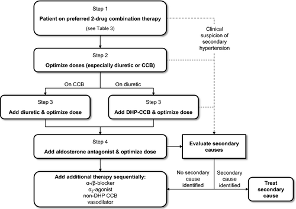

**Figure 3**

Example of an algorithm for pharmacologic management of resistant hypertension. In step 3, if thiazide diuretics are added, current (limited) data suggest that chlorthalidone may be the most effective option. In step 4, for patients intolerant of aldosterone antagonists, amiloride can be substituted. After step 4, most patients should be evaluated for secondary causes of hypertension if blood pressure remains uncontrolled. If none are found (or such evaluation is impractical or impossible), additional therapies can be added with their particular order based on patient-specific factors including cost, tolerability, comorbid disease states, and concomitant medications (see text also for additional considerations for specific therapies). CCB = calcium channel blocker; DHP = dihydropyridine.

#### Renin-Guided Therapy

Renin-guided therapy, based on extensive research, has emerged as a useful approach to the treatment of hypertension,55 and, by extension, it may hold promise in resistant hypertension as well. However, the use of renin-guided therapy in the general hypertensive population for clinical purposes remains controversial. This concept and its limitations were recently reviewed in detail.56 Briefly, renin-guided therapy is based on the concept that all chronic essential hypertension is sustained by excess sodium-volume content (referred to as “V” hypertension), excess renin-angiotensin-aldosterone system (RAAS) vasoconstriction (“R” hypertension), or some combination of both. A corollary to this concept is that all antihypertensive agents can be classified as anti-V (primarily treating excess sodium-volume content) or anti-R (primarily inhibiting some aspect of the renin-angiotensin system). Thus, by measuring plasma renin activity, one can determine whether volume or RAAS vasoconstriction is the primary driver of chronic blood pressure elevations and treat accordingly. The particular theoretical advantages of this approach in patients with resistant hypertension include more targeted antihypertensive therapy with less risk of adding ineffective or even pressor therapy,57 and faster attainment of blood pressure goals. Until more data become available in patients with resistant hypertension, renin-guided therapy may be better reserved for patients unresponsive to optimized drug regimens. Table 4 summarizes hypertension types according to this model and the corresponding renin-guided approach in patients with resistant hypertension.58

Table 4. Tailoring of Resistant Hypertension Therapy Based on Plasma Renin Activity Alone

| Hypertension Classification | Excessive Volume Dependence | Volume + Renin Dependence (Compensatory) | Renin + Volume Dependence | Excessive Renin Dependence |
| --- | --- | --- | --- | --- |
| Primary initial treatment | Anti-V drug | Anti-V drug | Anti-R drug | Anti-R drug |
| Effective plasma renin activitya | <0.65 | ≥0.65 | <0.65 | ≥0.65 |
| Subsequent treatment | Add anti-V drug | Add anti-R drug | Add anti-V drug | Add anti-R drug |

- Anti-V drugs include natriuretic and volume-mediated drugs: diuretics, dihydropyridine calcium channel blockers, α<sub>1</sub>-blockers, and vasodilators. Anti-R drugs include inhibitors of the renin-angiotensin system: angiotensin-converting enzyme (ACE) inhibitors, angiotensin receptor blockers (ARBs), direct renin inhibitors, β-blockers, central α<sub>2</sub>-agonists, and reserpine.
- Adapted from reference 58.
- <sup>*a*</sup> For all patients taking an ACE inhibitor or ARB, effective plasma renin activity (PRA) = 0.1 × measured PRA because ACE inihibitors and ARBs block 90% of the effective activity of the renin-angiotensin system in vivo. For all other patients, effective plasma renin activity = measured plasma renin activity.

More recently, some have advocated for measuring both plasma renin activity and aldosterone levels to guide therapy (Table 5).59 This approach essentially helps differentiate primary and secondary aldosteronism (elevated aldosterone secondary to elevated renin activity), as well as identifying uncommon cases of renal tubular sodium channel abnormalities (e.g., Liddle syndrome). However, this approach is unlikely to be significantly more useful than renin-guided therapy if primary hyperaldosteronism has been ruled out previously.

Table 5. Tailoring of Resistant Hypertension Therapy Based on Plasma Renin Activity and Aldosterone Levels

|  | Liddle Syndrome (and Sodium Channel Mutations) | Primary Hyperaldosteronism | Renal or Renovascular |
| --- | --- | --- | --- |
| Plasma renin activity | ↓ | ↓ | ↑ |
| Plasma aldosterone | ↓ | ↑ | ↑ |
| Tailored therapy | Amiloride | Aldosterone antagonist | ARB, DRI, ACE inhibitora |

- ARB = angiotensin receptor blocker; DRI = direct renin inhibitor; ACE = angiotensin-converting enzyme.
- <sup>*a*</sup> Some have advocated that ACE inhibitors should be considered second-line therapy after ARBs or DRIs for these patients due to non-ACE production of angiotensin II (also known as “ACE escape”).59

#### Chronotherapy

An additional approach receiving increased attention in recent years is the concept of chronotherapy—that is, targeting of antihypertensive therapy to a specific time of day. Chronotherapy stems from the findings that cardiovascular events are more common in patients not exhibiting the normal 10–20% reduction in nocturnal blood pressure (so-called nondippers) and that nocturnal blood pressure is more predictive of such events than is the morning surge in blood pressure.60 Several studies have suggested that administration of at least one antihypertensive agent in the evening significantly improves ambulatory blood pressure control, reduces the prevalence of nondipping, and reduces cardiovascular event rates by ~64% (68 vs 187 events over a median 5.6-year study period), compared with morning-only administration of all antihypertensive agents.60-62 These findings are certainly intriguing, particularly because this approach involves virtually no additional cost, with the only obvious disadvantage the possible burden of an additional administration time (and potential nonadherence). However, the study of chronotherapy is still in its infancy, and major questions remain regarding this approach, such as which agents are preferred for evening administration63 and whether excessive nocturnal blood pressure reduction might have unintended consequences (e.g., reduced ocular perfusion and consequent ischemic damage to the optic nerve leading to blindness).

### Pharmacologic Agents

#### Aldosterone Antagonists

As previously discussed, hyperaldosteronism is quite prevalent in patients with resistant hypertension. However, even in those not meeting the diagnosis for primary hyperaldosteronism based on the aldosterone-to-renin ratio, excess aldosterone production likely contributes substantially to treatment resistance.64 Consequently, aldosterone antagonism has been recommended as a first-line and effective strategy in patients with resistant hypertension regardless of the presence of demonstrable primary hyperaldosteronism.5

The use of aldosterone antagonists in patients with resistant hypertension first surfaced over a decade ago.65, 66 These early reports consisted of the results of two small single-arm open-label prospective studies of spironolactone 1 mg/kg65 or 25–50 mg66 once/day in patients with apparent resistant hypertension. In both studies, blood pressure reductions were substantial, on average ~20/10 mm Hg at 4–6 weeks after initiation, and were sustained for at least 6 months. Furthermore, spironolactone was equally effective for patients with and without primary hyperaldosteronism, and the magnitude of blood pressure reduction was not related to plasma aldosterone, 24-hour urinary aldosterone, plasma renin activity, or the aldosterone-to-renin ratio.66

In the ASCOT–Blood Pressure Lowering Arm (BPLA) trial, spironolactone was recommended as a fourth-line agent, at a median dose of 25 mg/day, after treatment with a strategy of amlodipine, perindopril, and doxazosin, or atenolol, bendroflumethiazide–potassium supplementation, and doxazosin.67 In the 1411 individuals with uncontrolled hypertension (mean number of medications 2.9) who had spironolactone added to their regimen, blood pressure was reduced by ~22/10 mm Hg after a median treatment duration of 1.3 years. These reductions were observed as early as 1 week after starting therapy and were not influenced by age, sex, smoking status, diabetes status, or initial treatment assignment (including the use of diuretics or ACE inhibitors). Adverse effects were relatively infrequent with spironolactone (13% of all treated individuals), with less than half resulting in treatment discontinuation; gynecomastia (occurring in 6% of treated individuals) and hyperkalemia were the most common adverse effects.

In the only placebo-controlled randomized study to date of low-dose spironolactone in resistant hypertension (the Addition of Spironolactone in Patients with Resistant Arterial Hypertension [ASPIRANT] trial), 117 patients were randomly assigned to spironolactone 25 mg or placebo, both administered once every morning.68 Notably, patients were not excluded on the basis of secondary forms of hypertension, but patients with severe hypertension (higher than 180 mm Hg systolic or 110 mm Hg diastolic blood pressure) were excluded. After 8 weeks of treatment, office blood pressure was reduced by ~15/7 and ~8/4 mm Hg in those treated with spironolactone and placebo, respectively, for a between-group difference of nearly 7/3 mm Hg, favoring spironolactone therapy; only systolic blood pressure was statistically significantly different between groups. The 24-hour ambulatory blood pressure monitoring revealed similar results, with a between-group difference of ~10/1 mm Hg, favoring spironolactone. However, whereas mean office blood pressure was relatively high (154/92 mm Hg) at baseline, mean baseline 24-hour ambulatory blood pressure was only 141/80 mm Hg, and more than a third of enrolled patients experienced a white-coat effect.

Eplerenone, a selective aldosterone antagonist, also appears to be effective in patients with resistant hypertension based on the results of a small 2008 single-arm prospective study.69 In 52 patients with resistant hypertension who were treated with a minimum of three antihypertensives (including a diuretic), eplerenone 50–100 mg once/day was added and titrated to effect. After 12 weeks of therapy, office blood pressure was reduced by ~18/8 mm Hg (from a baseline of 151/84 mm Hg) and 24-hour ambulatory blood pressure was reduced by ~12/6 mm Hg (from a baseline of 150/79 mm Hg). Not surprisingly, baseline blood pressure was the strongest predictor of eplerenone response (r ≈ 0.5, p<0.001), but as in previous studies of spironolactone, aldosterone levels and plasma renin activity poorly predicted change in blood pressure.

Taken together, aldosterone antagonism with low-dose spironolactone (25–50 mg once/day) or eplerenone (50–100 mg once/day) appears to be quite effective and is associated with relatively few adverse effects (foremost is hyperkalemia) in patients with true resistant hypertension, regardless of the level of excess aldosterone production. Moreover, aldosterone antagonists appear to be more effective alone or as a component of sequential nephron blockade (including furosemide and amiloride) than a strategy of sequential- or double-RAS blockade (i.e., ARB plus ACE inhibitor).70, 71 Unfortunately, claims data suggest that less than 6% of patients with resistant hypertension use aldosterone antagonists compared with nearly 16% who use combination ACE inhibitor plus ARB therapy.8 Blood pressure response to spironolactone appears to be comparable in patients with resistant hypertension and nonresistant hypertension,72 yet, curiously, aldosterone antagonists are rarely added to hypertension regimens, even in those with resistant hypertension. Whether earlier and more frequent use of aldosterone antagonists might be a more effective strategy in the general hypertension population, as it appears to be in chronic heart failure, is a question that remains unanswered.

### Other Approved Agents

Very few other agents have been adequately studied in patients with resistant hypertension, although current guidelines recommend consideration of older antihypertensives (e.g., minoxidil, hydralazine) for select patients.5 Unfortunately, these agents are fraught with adverse effects, and the small trials that have systematically examined them were generally methodologically weak (e.g., uncontrolled pre-/posttrials) and were performed prior to the advent of many of the currently available agents. Thus whether they are as effective in patients who are already receiving maximal doses of commonly used agents is unknown. Patients using minoxidil, in particular, require concomitant use of a β-blocker to prevent reflex tachycardia, as well as aggressive diuretic use due to minoxidil-induced sodium retention. Combinations of dihydropyridine and nondihydropyridine CCBs have been used effectively in patients with nonresistant hypertension, generally doubling blood pressure reduction compared with either class alone.73 However, no studies have prospectively assessed this combination in patients with resistant hypertension. Regardless, if this strategy is used, skillful use of pharmacokinetic interactions may offer additional blood pressure reductions because nondihydropyridine CCBs inhibit cytochrome P450 3A4 (diltiazem more than verapamil), the major metabolic pathway for the dihydropyridine CCBs.74 Finally, one recent but very small study of 6 subjects suggests a potential benefit of combined nitrate (e.g., isosorbide mononitrate) and phosphodiesterase-5 inhibitor (e.g., sildenafil) in the treatment of resistant hypertension.75

### Experimental Agents

#### Darusentan

Darusentan, a selective endothelin type A antagonist, is currently unavailable in the United States, but it has shown promise in treating resistant hypertension. In a randomized double-blind, placebo-controlled study, 379 individuals with resistant hypertension were assigned to darusentan 50, 100, or 300 mg, or placebo, administered once/day.76 After 14 weeks of therapy, office blood pressure was reduced by 9/5 mm Hg in the placebo group and 17/10, 18/10, and 18/11 mm Hg in the darusentan 50, 100, and 300-mg groups, respectively (p<0.0001 for all darusentan groups compared with placebo). Blood pressure reductions were not significantly different between groups, suggesting that 50 mg once/day (or possibly a lower dose) is a sufficiently high dose to induce substantial blood pressure lowering. Notably, edema occurred early (within 6 wks) and often in the darusentan groups (27%) relative to the placebo-treated patients (14%); in most patients (70%), edema was adequately treated with loop diuretic therapy. Incident edema was dose-dependent, and thus lower doses may attenuate this adverse effect while maintaining blood pressure lowering efficacy. Interestingly, darusentan-treated patients had a greater number of serious cardiac events (five total across all dose groups) than did placebo-treated patients (one case of sudden cardiac death). However, larger studies with much longer treatment duration are necessary to confirm that darusentan might truly impart greater adverse cardiovascular risk in patients with resistant hypertension. Interestingly, in the subsequent Optimized Doses of Darusentan as Compared to an Active Control in Resistant Hypertension (DORADO-AC) trial, darusentan, compared with placebo, did not significantly lower mean clinic systolic blood pressure (15-mm Hg reduction vs 14-mm Hg reduction); however, in the analysis of ambulatory blood pressure data, darusentan did lower mean systolic blood pressure by an additional 12 mm Hg compared with placebo (14- vs 2-mm Hg reduction, p<0.001).77

#### Aldosterone Synthase Inhibitors

Given the success of aldosterone antagonists, other agents similarly affecting aldosterone (or its downstream effects) may be of use in patients with resistant hypertension. Aldosterone synthase inhibitors are under active development and are effective in the treatment of primary hypertension. Based on the results of one phase II trial, the compound LCI699 at a dose of 1 mg once/day appears to have similar efficacy to eplerenone 50 mg twice/day.78 Whether these findings would be similar in patients with resistant hypertension can only be speculated, but one purported advantage of these agents is that, unlike aldosterone antagonists, aldosterone synthase inhibitors would not be expected to cause a compensatory rise in aldosterone, which would decrease systemic and cardiovascular exposure to the adverse fibrotic and inflammatory effects of aldosterone. However, aldosterone synthase inhibition with LCI699 also partially suppressed cortisol synthesis in some subjects.78 The long-term clinical significance of this effect is unknown.

### Nonpharmacologic Interventional Therapy

#### Renal Denervation

Autonomic control of the kidney is primarily mediated by postganglionic norepinephrine-releasing renal sympathetic nerves. Stimulation of the renal sympathetic nerves leads to dose-dependent elevations in blood pressure as follows: low-level stimulation activates renin release from juxtaglomerular cells, moderate levels of stimulation result in reduced urinary sodium excretion from activation of renal tubular cells in the ascending loop of Henle, and at the highest level of stimulation, renal vasoconstriction and reduced renal blood flow can occur.79

Selective renal sympathetic denervation is a relatively new therapy (with origins traceable to older “nonselective” surgical procedures) using catheter-based radiofrequency ablation applied multiple times directly to the renal nerve that has shown substantial promise in treating patients with resistant hypertension. The exact mechanism of blood pressure lowering with this procedure is not fully known, but numerous mechanisms have been hypothesized (Table 6). In the most rigorous trial published to date, 106 adults with resistant hypertension were randomly assigned to open-label renal denervation by using the Symplicity Catheter (Ardian Inc., Palo Alto, CA, USA) or standard pharmacologic management.80 At 1 month postintervention, blood pressure was reduced by a control-subtracted 20/7 mm Hg (p≤0.002) in the renal denervation group, with similar findings at 3 months postintervention (20/6 mm Hg reduction, p≤0.005) and even greater reduction at 6-months postintervention (33/12 mm Hg reduction, p<0.0001). A recent report incorporating 12-month data suggests a similar (or possibly slightly attenuated) systolic blood pressure reduction of 28 mm Hg compared with the control group (p=0.16 for 6-mo vs 12-mo data).81 These data suggest that renal denervation therapy is at least as effective, and possibly more so, than pharmacologic therapy at promoting sustained blood pressure lowering in patients with resistant hypertension. Moreover, the procedure appears to carry generally low risk, at least up to 1–2 years after the procedure. However, long-term data are lacking (most notably, safety data), renal denervation must be performed by specialists, and only a minority of patients with true resistant hypertension will be adequate candidates for such therapy.82 Furthermore, the procedure is relatively expensive—although likely cost effective—at a onetime cost ranging between $8000 and $15,000.83

Table 6. Possible Mechanisms of Blood Pressure Reduction from Nonpharmacologic Interventional Therapy for Resistant Hypertension

[output not shown]

- LVH = left ventricular hypertrophy; OSA = obstructive sleep apnea.

### Carotid Baroreceptor Activation Therapy

Carotid baroreceptors inhibit sympathetic cardiovascular stimulation and stimulate vagal traffic to the heart.84 In patients with hypertension, alterations in carotid baroreceptors occur that impair modulation of vagal traffic and result in a resetting of baroreceptor control of blood pressure.84 Consequently, electrical stimulation of carotid sinus baroreceptors using an implanted device termed *baroreflex activation therapy* augments parasympathetic activity and reduces sympathetic activity to various organs (Table 6).

In the Rheos Pivotal Trial, in which 265 individuals were implanted with the Rheos system (CVRx Inc., Minneapolis, MN, USA), systolic blood pressure was reduced by a mean ± SD of 16 ± 29 mm Hg from baseline (prior to system implantation) in patients who had their Rheos system turned on immediately (immediate therapy group) compared with a 9 ± 29 mm Hg reduction in patients who never had their system turned on (deferred therapy group, p=0.08).85 The proportion of patients achieving goal blood pressure (less than 140/90 mm Hg) was greater in the immediate therapy group compared with the deferred therapy group (p=0.005), but the proportion of responders (defined as a systolic blood pressure reduction of 10 mm Hg or more) was not significantly different between groups (54% in the immediate therapy group vs 46% in the deferred therapy group, p=0.97). This trial design has been criticized, primarily because treating investigators were allowed to adjust medication therapy in the deferred therapy group (likely resulting in a greater than expected blood pressure response in the absence of activation therapy) and that blood pressure was measured 4–6 hours after medication administration, rather than at trough times, which may have artifactually increased blood pressure response in the deferred therapy group. Thus additional larger trials that take these limitations into consideration may eventually show baroreceptor activation therapy to be more effective in patients with resistant hypertension.

### Biofeedback

Finally, biofeedback techniques, such as device-guided slow breathing exercises, appear to be effective in treating both general hypertension populations and patients with resistant hypertension. In one small uncontrolled trial using the RESPeRATE device (InterCure Ltd., Lod, Israel), 17 patients with resistant hypertension who performed slow-breathing exercises for 15 minutes daily for 8 weeks achieved a mean reduction in office and home blood pressures of ~13/7 and ~6/3 mm Hg, respectively, with 82% of patients classified as responders (more than 10 mm Hg systolic or more than 5 mm Hg diastolic blood pressure reduction).86

## Conclusion

Resistant hypertension is an increasingly common clinical problem in the United States and elsewhere. Patients with resistant hypertension are at increased risk for major adverse cardiovascular events, but the exact mechanism for this increased risk is not yet fully known. Appropriate management of these patients includes accurate diagnosis of truly drug-resistant hypertension, elimination of interfering substances, and a tailored treatment strategy. Such strategies should include lifestyle modifications and dietary management (in particular, sodium restriction) and rational therapeutic combinations of antihypertensive agents, ideally incorporating, at a minimum, thiazide diuretics, dihydropyridine CCBs, and an ACE inhibitor or ARB. Aldosterone antagonists have emerged as the most effective pharmacologic agent for these patients, and they can be used regardless of the presence of primary or secondary hyperaldosteronism. However, these agents remain vastly underused. For those patients refractory to pharmacologic therapy, interventional procedures such as renal denervation and possibly baroreceptor activation therapy may ultimately become appropriate therapeutic alternatives, but their use remains investigational at present.

[figure not shown]